# Презентация по лабораторной работе №11

Операционные системы

Федорова А.И

Российский университет дружбы народов, Москва, Россия

## Цели и задачи

Цель данной лабораторной работы - познакомиться с операционной системой Linux. Получить практические навыки работы с редактором Emacs.

## Материалы и методы

1. Ознакомиться с теоретическим материалом.
2. Ознакомиться с редактором emacs.
3. Выполнить упражнения.
4. Ответить на контрольные вопросы

## Выполнение лабораторной работы

Создаю файл lab07.sh с помощью комбинации Ctrl-x Ctrl-f (рис.fig:002).

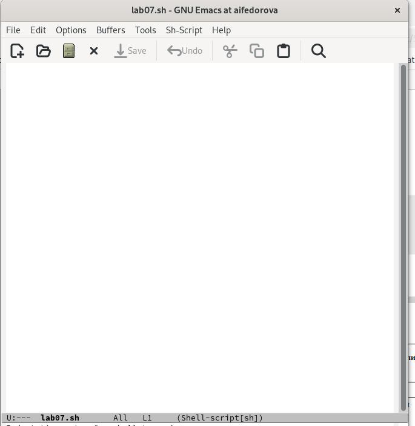

Создание файла

## Выполнение лабораторной работы

Прописываю в файле текст программы (рис.fig:003).

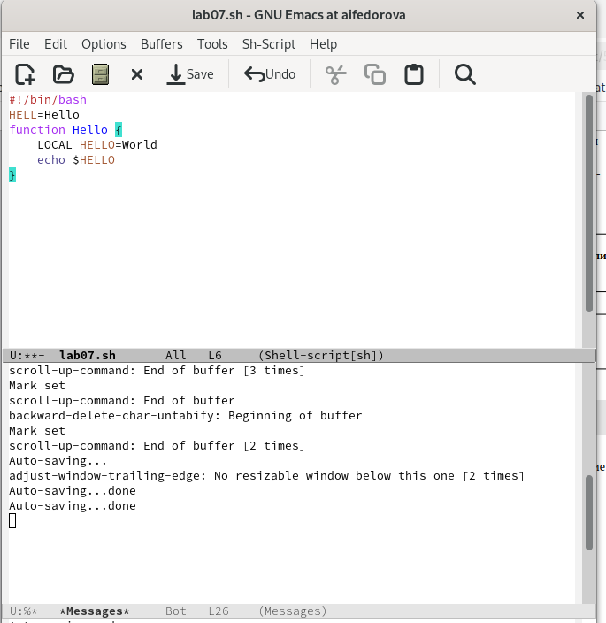

Редактирование файла

## Выполнение лабораторной работы

Сохраняю файл с помощью комбинации C-x C-s (рис.fig:004).

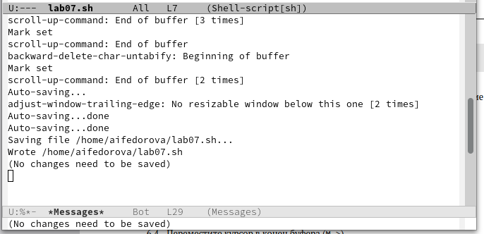

Сохранение изменений в файле

## Выполнение лабораторной работы

Вырезаю одной командой целую строку (С-k) (рис.fig:005).

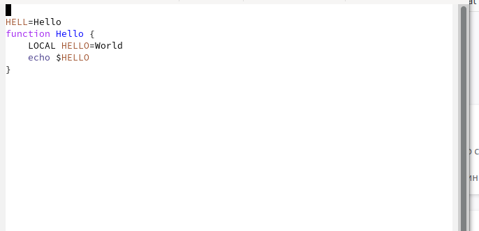

Вырезание строки

## Выполнение лабораторной работы

Вставляю эту строку в конец файла (C-y) (рис.fig:006).

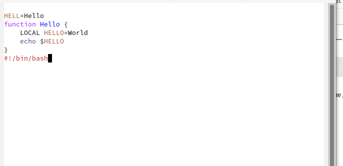

Вставка строки в конце файла

## Выполнение лабораторной работы

Выделияю область текста (C-space), копирую область в буфер обмена (M-w), вырезаю эту область с помощью C-w (рис.fig:007).

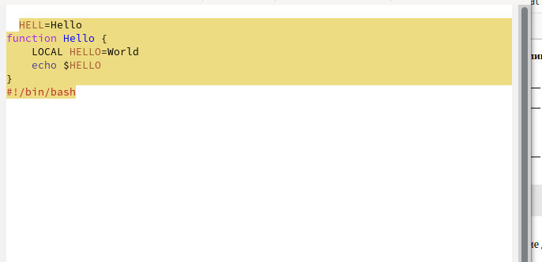

Вырезанная область

## Выполнение лабораторной работы

Вставляю область в конец файла (С-у)(рис.fig:008).

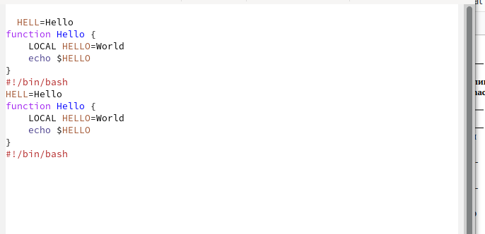

Вставка в конец файла

## Выполнение лабораторной работы

Отменяю последнее действие С-/ (рис.fig:009).

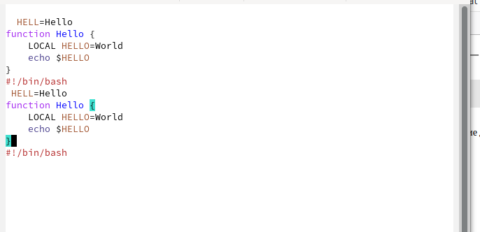

Отмена последнего действия

## Выполнение лабораторной работы

Перевожу курсор в начало строки С-а (рис.fig:010).

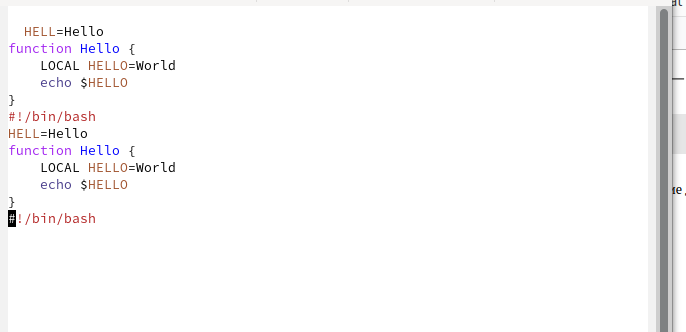

Курсор в начале строки

## Выполнение лабораторной работы

Перемещаю курсор в конец строки С-е ( рис. fig:011).

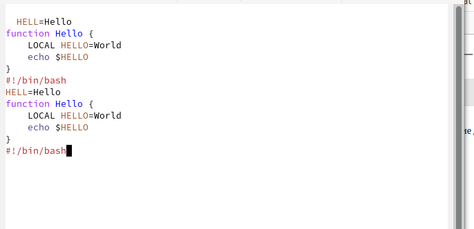

Курсор в конце строки

## Выполнение лабораторной работы

Перемещаю курсор в начало файла М-< ( рис. fig:012).

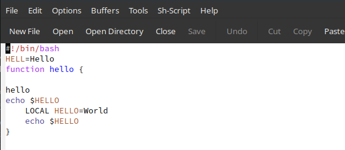

Начало буфер

## Выполнение лабораторной работы

Перемещаю курсор в конец файлаM->(рис. fig:013).

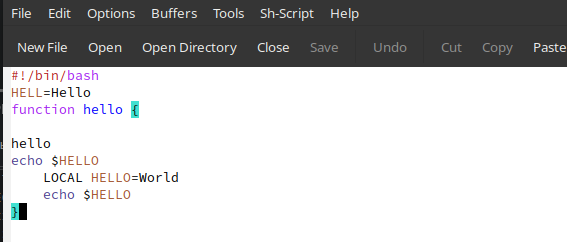

Конец буфера

## Выполнение лабораторной работы

Открываю список активных буферов в другом окне C-x C-b (рис.fig:014).

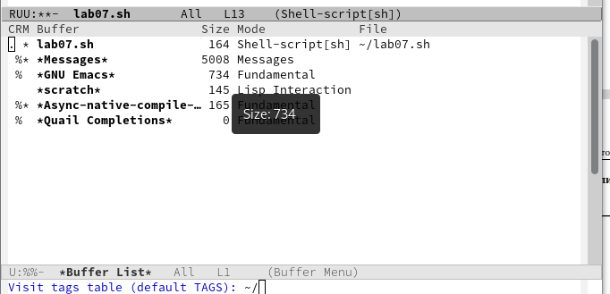

Список активных буферов

## Выполнение лабораторной работы

Переключаюсь на другой буфер C-x o (рис.fig:015).

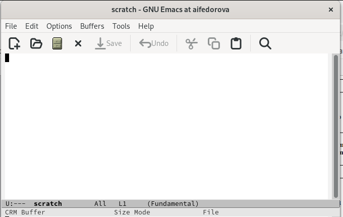

Другое окно буфера

## Выполнение лабораторной работы

Закрываю окно другого буфера C-x 0 (рис. fig:016).

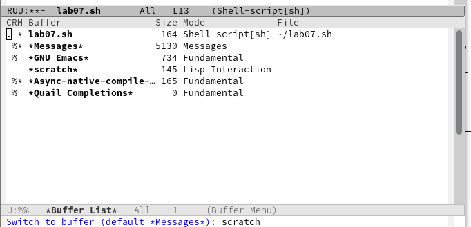

Закрытие буфера

## Выполнение лабораторной работы

Открываю другой буфер без вывода их списка на экран с помощью C-x b(рис. fig:017).

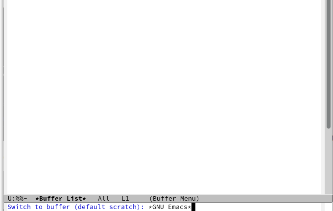

Открытие другого буфера

## Выполнение лабораторной работы

Делю фрейм на 4 части: сначала на два окна по вертикали (C-x 3), а затем каждое из этих окон на две части по горизонтали (C-x 2) (рис. fig:018).

[figure not shown]

Четыре окна

## Выполнение лабораторной работы

В каждом из четырех созданных окон с помощью C-x b открыла разные буферы и (рис.fig:019).

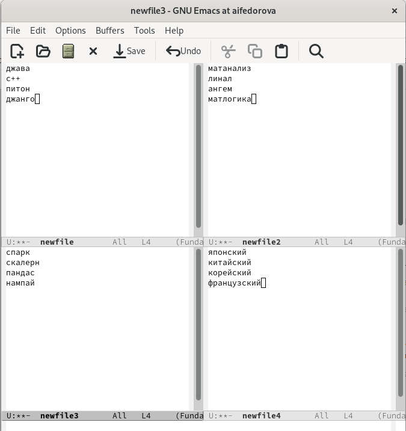

Открытие буферов в четырех окнах

## Выполнение лабораторной работы

Перехожу в режим поиска с помощью C-s, ищу слова в тексте, они подсвечиваются (рис. fig:020).

[figure not shown]

Режим поиска

## Выполнение лабораторной работы

С помощью C-g выхожу из режима поиска, снимается выделение (рис. fig:021).

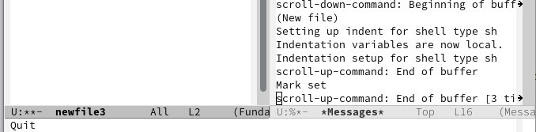

Выход из режима поиска

## Выполнение лабораторной работы

Перехожу в режим поиска и замены с помощью M-%, ввожу какое слово хочу заменить, затем ввожу на какое хочу заменить (рис. fig:023).

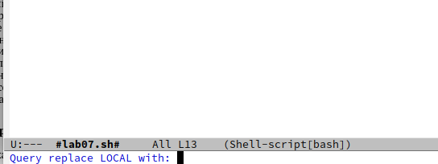

Замена слова

## Выполнение лабораторной работы

Видим, что слова были заменены успешно (рис.fig:023).

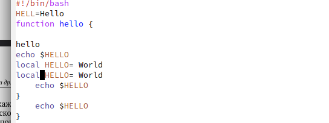

Слово заменено

## Выполнение лабораторной работы

С помощью M+s перехожу в другой режим поиска. Он отличается от предыдущего тем, что выводит результат в отдельном окне от окна буфера (рис. fig:024).

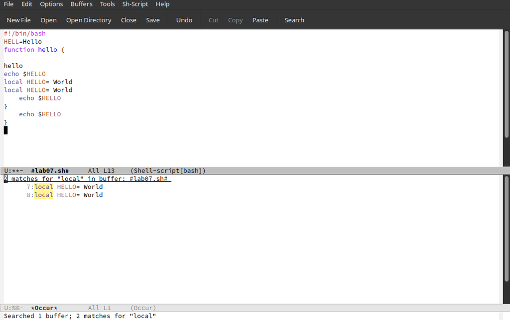

Режим поиска

## Результаты

В ходе данной лаборатрной работы я познакомилась с операционной системой Linuх, получила практические навыки работы с редактором Emacs.

## Итоговый слайд

Спасибо за внимание!